# Case Study1: Heart Disease Prediction Model

### Is target column balance or imbalance?

```r
dist_target_column <- table(df$target)
dist_target_column
```

```
##
##   0   1
## 138 164
```

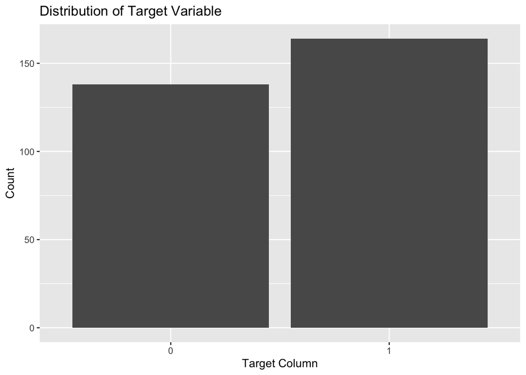

```r
ggplot(df, aes(x = factor(target))) +
  geom_bar() +
  labs(title = "Distribution of Target Variable",
       x = "Target Column",
       y = "Count")
```

- As, 0 ( No disease) have 138 value and 1 ( Disease) have 164 value, there is no significant difference in distribution so, it is **balance**.

### EDA

#### 1. Age vs Target column

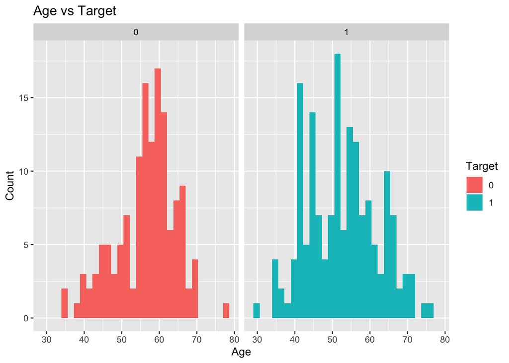

```r
ggplot(df, mapping = aes(x = age, fill = target)) +
  geom_histogram() +
  facet_wrap(vars(target)) +
  labs(title = "Age vs Target", x = "Age", y = "Count", fill = "Target")
```

- As, above plot, age between 40 to 60 have high probability of having a heart disease as compare to younger age.

#### 2. CP vs Target

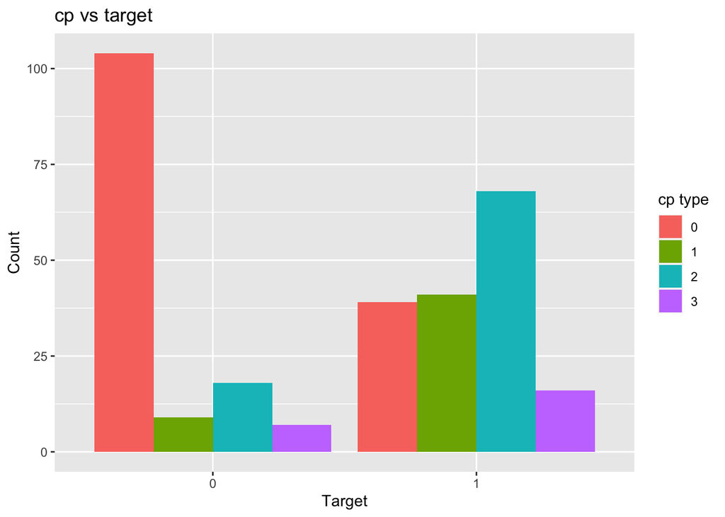

```r
ggplot(df, mapping = aes(x=target, fill = cp)) +
  geom_bar(position = "dodge") +
  labs(title = "cp vs target", x = "Target", y = "Count", fill = "cp type")
```

- Here, 2 (non-anginal chest pain) have highest count for a person to have a heart disease, while 3 (asymptomatic) have lowest count.
- There is high count of 0 (typical angina chest pain) for non heart disease in comparison with those who have heart disease.
- There is relationship between chest pain column and target column.

#### 3. Sex vs Target

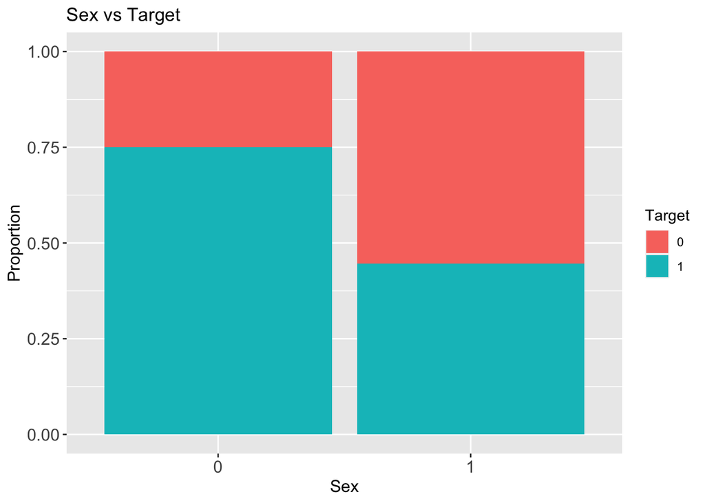

```r
ggplot(df, mapping = aes(x = sex, fill = target)) +
  geom_bar(position = "fill") +
  labs(x = "Sex", y = "Proportion", fill = "Target", title = 'Sex vs Target') +
  theme(axis.text.x = element_text(size = 12), axis.title.x = element_text(size = 12),
        axis.title.y = element_text(size = 12), axis.text.y = element_text(size = 12))
```

- In above bar plot, male(0) have high probability of heart disease in comparison to female (1). There is relation between sex and target class.

### 4. fbs vs target

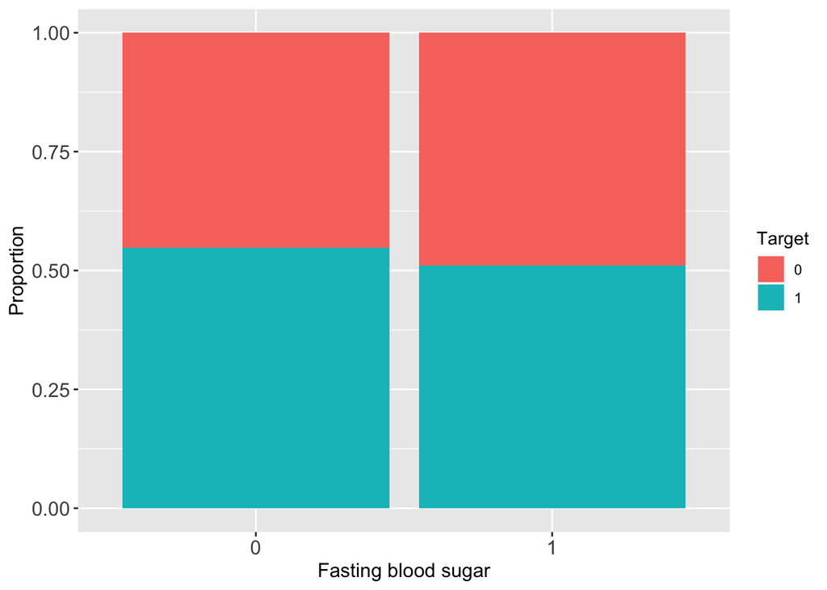

```r
# 0 low | 1 high

ggplot(df, mapping = aes(x = fbs, fill = target)) +
  geom_bar(position = "fill") +
  labs(x = "Fasting blood sugar", y = "Proportion", fill = "Target") +
  theme(axis.text.x = element_text(size = 12), axis.title.x = element_text(size = 12),
        axis.title.y = element_text(size = 12), axis.text.y = element_text(size = 12))
```

- There is similar distribution between (1) high blood sugar > 120 mg/dl and (0) is relatively similar, so fbs column have no correlation with target class.

#### 5. exang vs target

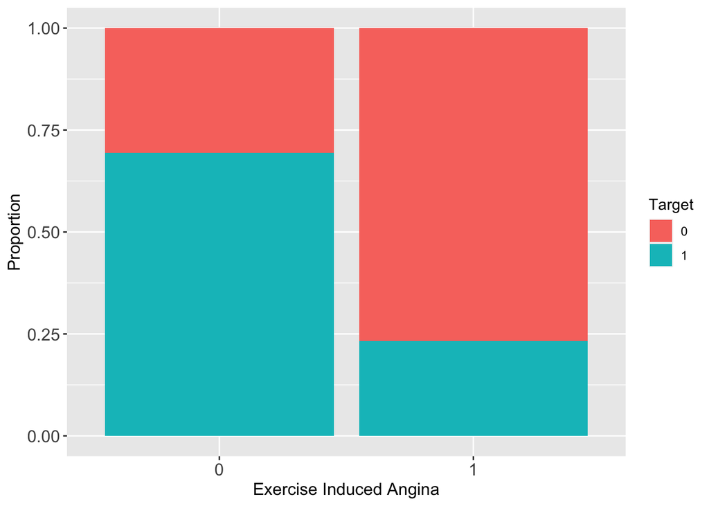

```r
# 1 = yes, 0 = no

ggplot(df, mapping = aes(x = exang, fill = target)) +
  geom_bar(position = "fill") +
  labs(x = "Exercise Induced Angina", y = "Proportion", fill = "Target") +
  theme(axis.text.x = element_text(size = 12), axis.title.x = element_text(size = 12),
        axis.title.y = element_text(size = 12), axis.text.y = element_text(size = 12))
```

- Here, patient who did not have exercise induced angina 0 (no) show high probability of having heart disease compare to those who experience (1). There seems correlation between target class.

#### 6. slope vs target

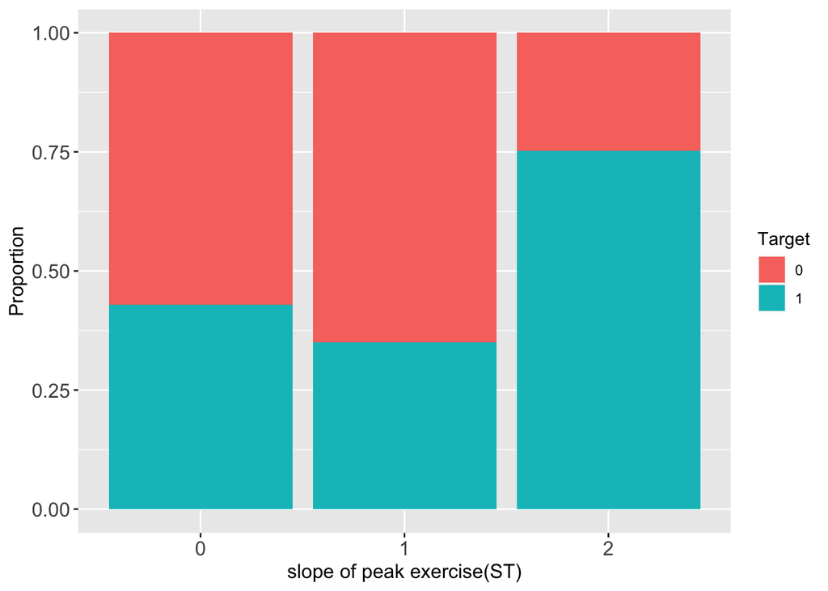

```r
ggplot(df, mapping = aes(x = slope, fill = target)) +
  geom_bar(position = "fill") +
  labs(x = "slope of peak exercise(ST)", y = "Proportion", fill = "Target") +
  theme(axis.text.x = element_text(size = 12), axis.title.x = element_text(size = 12),
        axis.title.y = element_text(size = 12), axis.text.y = element_text(size = 12))
```

- Here, 2 (Down sloping) has probability of have heart disease with low probability (flat), showing potential to predict target class.

#### 7. thal vs target

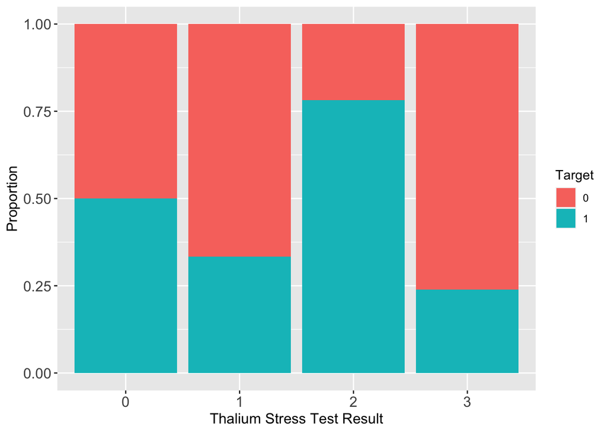

```r
ggplot(df, mapping = aes(x = thal, fill = target)) +
  geom_bar(position = "fill") +
  labs(x = "Thalium Stress Test Result", y = "Proportion", fill = "Target") +
  theme(axis.text.x = element_text(size = 12), axis.title.x = element_text(size = 12),
        axis.title.y = element_text(size = 12), axis.text.y = element_text(size = 12))
```

- Here, 2 type (thal) have high proportion of heart disease compare to other types.